# Module 2: Recommended Exercises - Solution

TMA4268 Statistical Learning V2025

Sara Martino, Stefanie Muff, Kenneth Aase

Department of Mathematical Sciences, NTNU

January 22, 2025

Last changes: 2025-01-14

# Problem 1

1. Classification

Example 1: Diagnosing cancer. Response: cancer (yes/no). Predictors: smoking status, age, family history, gene expression etc. Goal: prediction.

Example 2: Understanding stock market price direction. Response: up/down. Predictors: yesterday’s price movement change, two previous days price movement etc. Goal: inference.

Example 3: Flower species. Response: species. Predictors: color, height, leaves, etc. Goal: prediction.

2. Regression

Example 1: Life expectancy. Response: age of death. Predictors: current age, gender, resting heart rate, resting breath rate etc. Goal: prediction.

Example 2: Price of a house. Response: Price. Predictors: age of house, average price in neighborhood, crime rate, distance to city center, distance to school, etc. Goal: prediction.

Example 3: What affects O2-uptake. Response: O2-uptake. Predictors: gender, age, amount of weekly exercise, type of exercise, smoking, heart disease, etc. Goal: inference.

# Problem 2

1. Based on the three different models compared here, the rigid method has the highest test MSE. However, this does not always have to be the case. For instance, in figure 2.10, we see that the most flexible model has the highest test MSE. See also figure 2.12 that summarizes the last three figures and shows some of the variation. So in general we cannot say anything certain about how the test MSE will vary based on model flexibility, this will depend on how the training data compares to the test data, and other model characteristics. However (though the question does not ask this), the *training* MSE will always decrease as the flexibility increases.
2. A small (test) variance implies an underfit to the data.
3. See figure 2.12. Underfit - low variance - high bias. Overfit - high variance - low bias. We wish to find a model that lies somewhere in-between, with low variance *and* low bias.

# Problem 3

```r
#install.packages("ISLR")
library(ISLR)
data(Auto)
```

```r
str(Auto)
```

```
## 'data.frame':    392 obs. of  9 variables:
##  $ mpg         : num  18 15 18 16 17 15 14 14 14 15 ...
##  $ cylinders   : num  8 8 8 8 8 8 8 8 8 8 ...
##  $ displacement: num  307 350 318 304 302 429 454 440 455 390 ...
##  $ horsepower  : num  130 165 150 150 140 198 220 215 225 190 ...
##  $ weight      : num  3504 3693 3436 3433 3449 ...
##  $ acceleration: num  12 11.5 11 12 10.5 10 9 8.5 10 8.5 ...
##  $ year        : num  70 70 70 70 70 70 70 70 70 70 ...
##  $ origin      : num  1 1 1 1 1 1 1 1 1 1 ...
##  $ name        : Factor w/ 304 levels "amc ambassador brougham",..: 49 36 231 14 161 141 54 223 241 2 ...
```

```r
summary(Auto)
```

```
##       mpg          cylinders      displacement     horsepower        weight
##  Min.   : 9.00   Min.   :3.000   Min.   : 68.0   Min.   : 46.0   Min.   :1613
##  1st Qu.:17.00   1st Qu.:4.000   1st Qu.:105.0   1st Qu.: 75.0   1st Qu.:2225
##  Median :22.75   Median :4.000   Median :151.0   Median : 93.5   Median :2804
##  Mean   :23.45   Mean   :5.472   Mean   :194.4   Mean   :104.5   Mean   :2978
##  3rd Qu.:29.00   3rd Qu.:8.000   3rd Qu.:275.8   3rd Qu.:126.0   3rd Qu.:3615
##  Max.   :46.60   Max.   :8.000   Max.   :455.0   Max.   :230.0   Max.   :5140
##
##   acceleration        year           origin                      name
##  Min.   : 8.00   Min.   :70.00   Min.   :1.000   amc matador       :  5
##  1st Qu.:13.78   1st Qu.:73.00   1st Qu.:1.000   ford pinto        :  5
##  Median :15.50   Median :76.00   Median :1.000   toyota corolla    :  5
##  Mean   :15.54   Mean   :75.98   Mean   :1.577   amc gremlin       :  4
##  3rd Qu.:17.02   3rd Qu.:79.00   3rd Qu.:2.000   amc hornet        :  4
##  Max.   :24.80   Max.   :82.00   Max.   :3.000   chevrolet chevette:  4
##                                                  (Other)           :365
```

The dimensions are $392$ observations (rows) of $9$ variables (columns). See from looking at the structure (`str()`) and `summary()` origin (encoded by values $1,2,3$) and name (name of the car) are qualitative predictors. The rest of the predictors are quantitative.

To see the range of the quantitative predictors, either apply the `range()` function to each column with a quantitative predictor separately

```r
range(Auto[, 1])
```

```
## [1]  9.0 46.6
```

```r
range(Auto[, 3])
```

```
## [1]  68 455
```

```r
range(Auto[, 4])
```

```
## [1]  46 230
```

```r
range(Auto[, 5])
```

```
## [1] 1613 5140
```

```r
range(Auto[, 6])
```

```
## [1]  8.0 24.8
```

```r
range(Auto[, 7])
```

```
## [1] 70 82
```

or use the `sapply()` function to run the `range()` function on the specified columns with a single line of code:

```r
quant <- 1:7
sapply(Auto[, quant], range)
```

```
##       mpg cylinders displacement horsepower weight acceleration year
## [1,]  9.0         3           68         46   1613          8.0   70
## [2,] 46.6         8          455        230   5140         24.8   82
```

To get the sample mean and sample standard deviation of the quantitative predictors, we can again either use the `sapply()` function in the same manner as above, or apply the `mean()` and `sd()` commands column-wise.

```r
#mean
sapply(Auto[, quant], mean)
```

```
##          mpg    cylinders displacement   horsepower       weight acceleration
##    23.445918     5.471939   194.411990   104.469388  2977.584184    15.541327
##         year
##    75.979592
```

```r
#or
mean(Auto[, 1])
```

```
## [1] 23.44592
```

```r
mean(Auto[, 2])
```

```
## [1] 5.471939
```

```r
mean(Auto[, 3])
```

```
## [1] 194.412
```

```r
mean(Auto[, 4])
```

```
## [1] 104.4694
```

```r
mean(Auto[, 5])
```

```
## [1] 2977.584
```

```r
mean(Auto[, 6])
```

```
## [1] 15.54133
```

```r
mean(Auto[, 7])
```

```
## [1] 75.97959
```

```r
#or
colMeans(Auto[, quant])
```

```
##          mpg    cylinders displacement   horsepower       weight acceleration
##    23.445918     5.471939   194.411990   104.469388  2977.584184    15.541327
##         year
##    75.979592
```

```r
#sd
sapply(Auto[, quant], sd)
```

```
##          mpg    cylinders displacement   horsepower       weight acceleration
##     7.805007     1.705783   104.644004    38.491160   849.402560     2.758864
##         year
##     3.683737
```

```r
#or
sd(Auto[, 1])
```

```
## [1] 7.805007
```

```r
sd(Auto[, 2])
```

```
## [1] 1.705783
```

```r
sd(Auto[, 3])
```

```
## [1] 104.644
```

```r
sd(Auto[, 4])
```

```
## [1] 38.49116
```

```r
sd(Auto[, 5])
```

```
## [1] 849.4026
```

```r
sd(Auto[, 6])
```

```
## [1] 2.758864
```

```r
sd(Auto[, 7])
```

```
## [1] 3.683737
```

Remove 10th to 85th observations and look at the range, mean and standard deviation of the reduced set. We now only show the solutions using `sapply()` to save space.

```r
#remove observations
ReducedAuto <- Auto[-c(10:85), ]

#range, mean and sd
sapply(ReducedAuto[, quant], range)
```

```
##       mpg cylinders displacement horsepower weight acceleration year
## [1,] 11.0         3           68         46   1649          8.5   70
## [2,] 46.6         8          455        230   4997         24.8   82
```

```r
sapply(ReducedAuto[, quant], mean)
```

```
##          mpg    cylinders displacement   horsepower       weight acceleration
##    24.404430     5.373418   187.240506   100.721519  2935.971519    15.726899
##         year
##    77.145570
```

```r
sapply(ReducedAuto[, quant], sd)
```

```
##          mpg    cylinders displacement   horsepower       weight acceleration
##     7.867283     1.654179    99.678367    35.708853   811.300208     2.693721
##         year
##     3.106217
```

We make a scatter plot of the full dataset using the `ggpairs()` function.

```r
library(GGally)
```

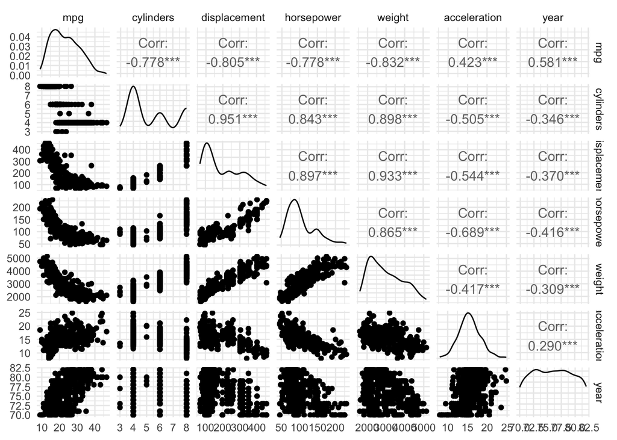

```r
ggpairs(Auto[, quant]) + theme_minimal()
```

We see that there seems to be strong relationships (based on curve trends and correlation) between the pairs: `mpg` and `displacement`, `mpg` and `horsepower`, `mpg` and `weight`, `displacement` and `horsepower`, `displacement` and `weight`, `horsepower` and `weght`, and `horsepower` and `acceleration`.

6. Wish to predict gas mileage based on the other variables. From the scatter plot we see that `displacement`, `horsepower` and `weight` could be good choices for prediction of `mpg`. Check if the qualitative predictors could also be good choices by plotting them against `mpg`.

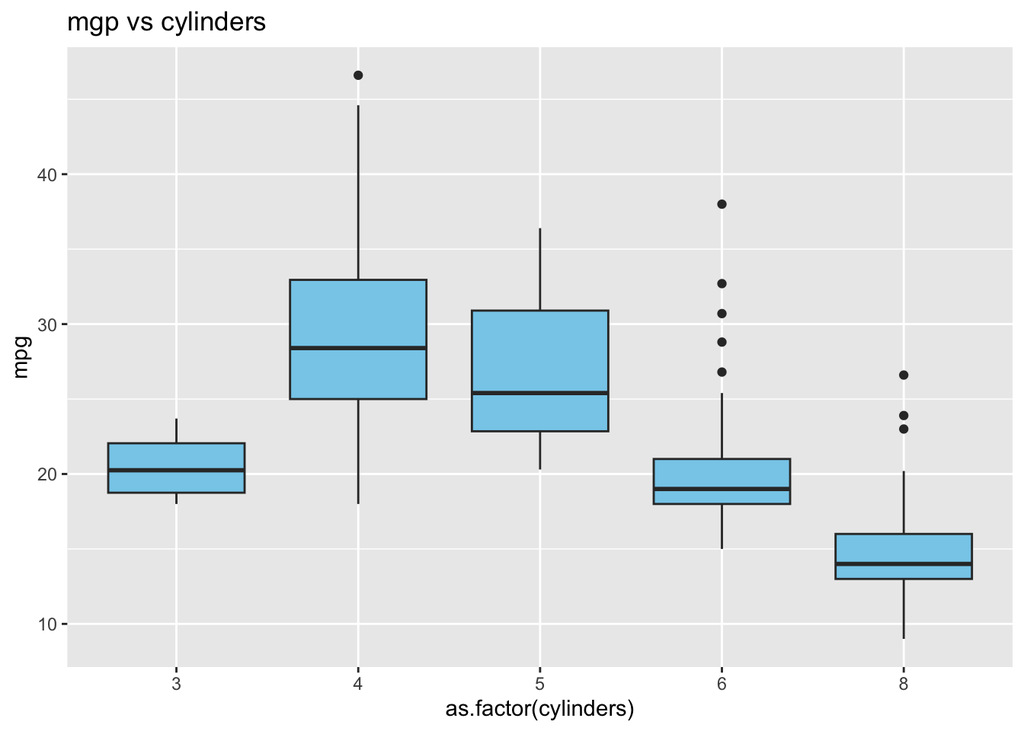

```r
ggplot(Auto, aes(as.factor(cylinders), mpg)) +
  geom_boxplot(fill = "skyblue") +
  labs(title = "mgp vs cylinders")
```

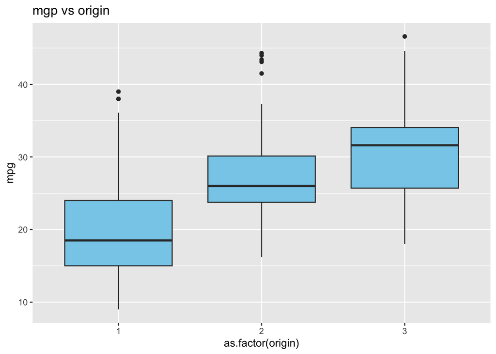

```r
ggplot(Auto, aes(as.factor(origin), mpg)) +
  geom_boxplot(fill = "skyblue") +
  labs(title = "mgp vs origin")
```

From these plots we see that both `cylinders` and `origin` could be good choices for prediction of `mgp`, because the miles per gallon (mpg) seems to depend on these two variables.

7. To find the correlation of the given variables, we need the covariance of these variable as well as the standard deviations, which are both available in the covariance matrix. Remember the the variance of each variable is given in the diagonal of the covariance matrix.

```r
covMat <- cov(Auto[, quant])
covMat[1, 2] / (sqrt(covMat[1, 1]) * sqrt(covMat[2, 2]))
```

```
## [1] -0.7776175
```

```r
covMat[1, 3] / (sqrt(covMat[1, 1]) * sqrt(covMat[3, 3]))
```

```
## [1] -0.8051269
```

```r
covMat[1, 4] / (sqrt(covMat[1, 1]) * sqrt(covMat[4, 4]))
```

```
## [1] -0.7784268
```

```r
cor(Auto[, quant])
```

```
##                     mpg  cylinders displacement horsepower     weight
## mpg           1.0000000 -0.7776175   -0.8051269 -0.7784268 -0.8322442
## cylinders    -0.7776175  1.0000000    0.9508233  0.8429834  0.8975273
## displacement -0.8051269  0.9508233    1.0000000  0.8972570  0.9329944
## horsepower   -0.7784268  0.8429834    0.8972570  1.0000000  0.8645377
## weight       -0.8322442  0.8975273    0.9329944  0.8645377  1.0000000
## acceleration  0.4233285 -0.5046834   -0.5438005 -0.6891955 -0.4168392
## year          0.5805410 -0.3456474   -0.3698552 -0.4163615 -0.3091199
##              acceleration       year
## mpg             0.4233285  0.5805410
## cylinders      -0.5046834 -0.3456474
## displacement   -0.5438005 -0.3698552
## horsepower     -0.6891955 -0.4163615
## weight         -0.4168392 -0.3091199
## acceleration    1.0000000  0.2903161
## year            0.2903161  1.0000000
```

We see that the obtained correlations coincide with the given elements in the correlation matrix.

# Problem 4

1. Simulate values from the four multivariate distributions using `mvnorm()`.

```r
# Simulate 1000 values from the multivariate normal distribution 4 times, with
# 4 different covariance matrices
library(MASS)
n <- 1000
mu <- c(2, 3)
set1 <- data.frame(mvrnorm(n, mu, Sigma = matrix(c(1, 0, 0, 1), ncol = 2)))
colnames(set1) <- c("x1", "x2")

set2 <- data.frame(mvrnorm(n, mu, Sigma = matrix(c(1, 0, 0, 5), ncol = 2)))
colnames(set2) <- c("x1", "x2")

set3 <- data.frame(mvrnorm(n, mu, Sigma = matrix(c(1, 2, 2, 5), ncol = 2)))
colnames(set3) <- c("x1", "x2")

set4 <- data.frame(mvrnorm(n, mu, Sigma = matrix(c(1, -2, -2, 5), ncol = 2)))
colnames(set4) <- c("x1", "x2")
```

2. Plot the simulated distribtions

```r
#install.packages("patchwork")
library(patchwork)
```

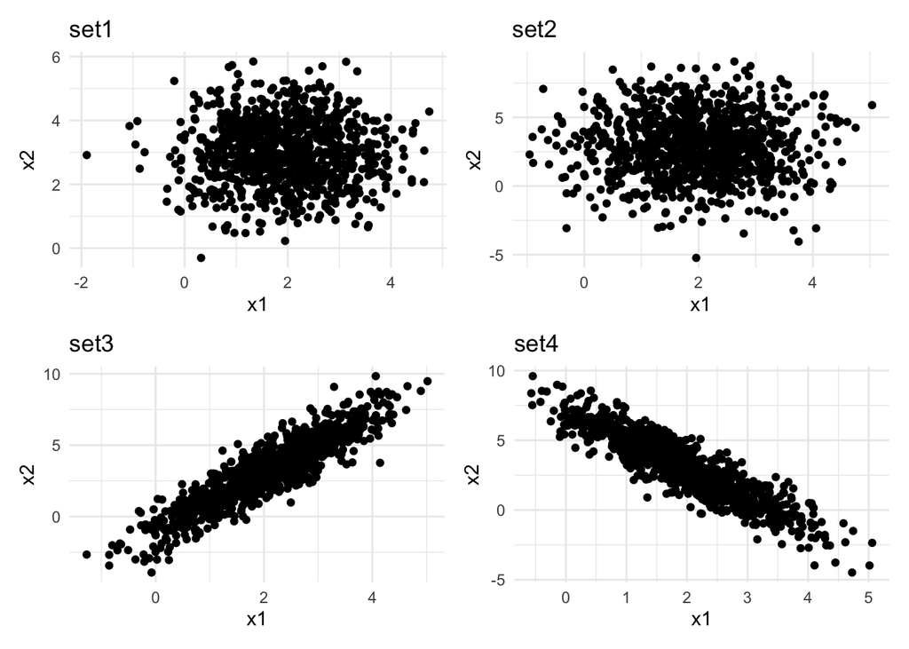

```r
p1 <- ggplot(set1, aes(x = x1, y = x2)) + geom_point() + labs(title = "set1") + theme_minimal()
p2 <- ggplot(set2, aes(x = x1, y = x2)) + geom_point() + labs(title = "set2") + theme_minimal()
p3 <- ggplot(set3, aes(x = x1, y = x2)) + geom_point() + labs(title = "set3") + theme_minimal()
p4 <- ggplot(set4, aes(x = x1, y = x2)) + geom_point() + labs(title = "set4") + theme_minimal()
(p1 + p2) / (p3 + p4)
```

# Problem 5

1. We sample from the model $y=x^2+\epsilon$ where $\epsilon \sim \mathcal{N}(0,2^2)$ and $x\in \{-2,-1.9,-1.8,...,3.8,3.9,4\}$. This means that $y \sim \mathcal{N}(x^2,2^2)$. A total of $100$ samples from this model are generated for each of the $61$ $x$’s.  
   See comments in code for further explanations.

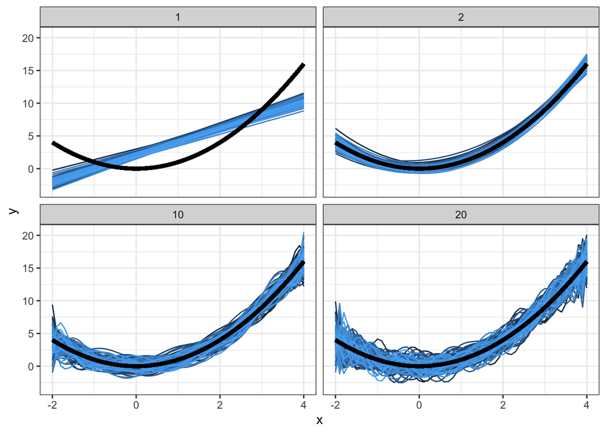

```r
set.seed(2) # to reproduce

M <- 100 # repeated samplings, x fixed
nord <- 20 # order of polynomials

#------
# We make a sequence of 61 points, x.
# These are the points for which we evaluate the function f(x).
x <- seq(from = -2, to = 4, by = 0.1)

truefunc <- function(x) {
  return(x^2) # The true f(x)=x^2.
}

# We find f(x) for each element in vector x.
true_y <- truefunc(x)

# Noise (epsilon) is sampled from a normal distribution and stored in this matrix.
# Each column corresponds to one value of x.
error <- matrix(rnorm(length(x) * M, mean = 0, sd = 2),
                nrow = M,
                byrow = TRUE)

# The 100 samples or the observations are stored in this matrix. Each row is a simulation.
ymat <- matrix(rep(true_y, M), byrow = TRUE, nrow = M) + error

#------
# Based on the response y_i and the x_i's, we fit a polynomial model of degree
# 1, ..., 20. This means that we assume y_i~Normal(x_i^j,0).
predictions_list <- lapply(1:nord, matrix, data = NA, nrow = M, ncol = ncol(ymat))
for (i in 1:nord) {
  for (j in 1:M) {
    predictions_list[[i]][j, ] <- predict(lm(ymat[j, ] ~ poly(x, i, raw = TRUE)))
  }
}

# Plotting -----

library(tidyverse) # The tidyverse contains ggplot2, as well as tidyr and dplyr,
# which we can use for dataframe manipulation.

list_of_matrices_with_deg_id <-
  lapply(1:nord,
         function(poly_degree) {
           cbind(predictions_list[[poly_degree]],
                 simulation_num = 1:M, poly_degree)
         }
  )
# Now predictions_list is a list with 20 entries, where each entry is a matrix
# with 100 rows, where each row is the predicted polynomial of that degree.
# We also have a column for the simulation number, and a column for polynomial degree.

# Extract each matrix and bind them to one large matrix
stacked_matrices <-  NULL
for (i in 1:nord) {
  stacked_matrices <-
    rbind(stacked_matrices, list_of_matrices_with_deg_id[[i]])
}
stacked_matrices_df <- as.data.frame(stacked_matrices)

# Convert from wide to long (because that is the best format for ggplot2)
long_predictions_df <- pivot_longer(stacked_matrices_df,
                                    !c(simulation_num, poly_degree),
                                    values_to = "y")

# Now we can use ggplot2!
# We just want to plot for degrees 1, 2, 10 and 20.
# Add x-vector to dataframe:
plotting_df <- cbind(long_predictions_df, x = x) %>%
  filter(poly_degree %in% c(1, 2, 10, 20)) # Keep only the predictions for some degrees

ggplot(plotting_df, aes(x = x, y = y, group = simulation_num)) +
  geom_line(aes(color = simulation_num)) +
  geom_line(aes(x = x, y = x^2), size = 1.5) +
  facet_wrap(~ poly_degree) +
  theme_bw() +
  theme(legend.position = "none")
```

The upper left plot shows 100 predictions when we assume that $y$ is a linear function of $x$, the upper right plot hows 100 predictions when we assume that $y$ is function of poynomials up to $x^2$, the lower left plot shows 100 predictions when we assume $y$ is a function of polynomials up to $x^{10}$ and the lower right plot shows 100 predictions when assuming $y$ is a function of polynomials up to $x^{20}$.

2. Run the code attached and consider the following plots:

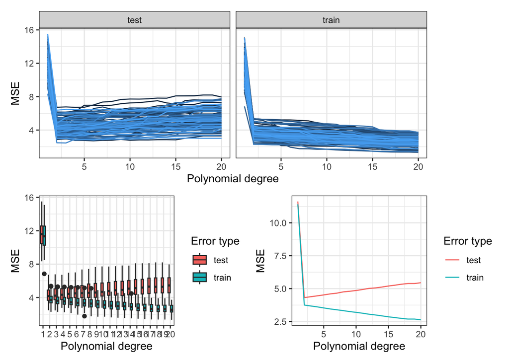

```r
set.seed(2) # to reproduce
M <- 100 # repeated samplings,x fixed but new errors
nord <- 20

x <- seq(from = -2, to = 4, by = 0.1)
truefunc <- function(x) {
  return(x^2)
}
true_y <- truefunc(x)
error <- matrix(rnorm(length(x) * M, mean = 0, sd = 2), nrow = M, byrow = TRUE)
testerror <- matrix(rnorm(length(x) * M, mean = 0, sd = 2), nrow = M, byrow = TRUE)
ymat <- matrix(rep(true_y, M), byrow = TRUE, nrow = M) + error
testymat <- matrix(rep(true_y, M), byrow = TRUE, nrow = M) + testerror

predictions_list <- lapply(1:nord, matrix, data = NA, nrow = M, ncol = ncol(ymat))
for (i in 1:nord) {
  for (j in 1:M) {
    predictions_list[[i]][j, ] <- predict(lm(ymat[j, ] ~ poly(x, i, raw = TRUE)))
  }
}

trainMSE <- lapply(1:nord,
                   function(poly_degree) {
                     rowMeans((predictions_list[[poly_degree]] - ymat)^2)
                   }
)
testMSE <- lapply(1:nord,
                  function(poly_degree) {
                    rowMeans((predictions_list[[poly_degree]] - testymat)^2)
                  }
)

# Plotting -----
library(tidyverse) # The tidyverse contains ggplot2, as well as tidyr and dplyr,
# which we can use for dataframe manipulation.

# Convert each matrix in the list form wide to long
# (because that is the best format for ggplot2)
list_train_MSE <- lapply(1:nord, function(poly_degree) {
  cbind(error = trainMSE[[poly_degree]],
        poly_degree,
        error_type = "train",
        simulation_num = 1:M)
})
list_test_MSE <- lapply(1:nord, function(poly_degree) {
  cbind(error = testMSE[[poly_degree]],
        poly_degree,
        error_type = "test",
        simulation_num = 1:M)
})

# Now predictions_list is a list with 20 entries, where each entry is a matrix
# with 100 rows, where each row is the predicted polynomial of that degree.

stacked_train <- NULL
for (i in 1:nord) {
  stacked_train <-
    rbind(stacked_train, list_train_MSE[[i]])
}
stacked_test <- NULL
for (i in 1:nord) {
  stacked_test <-
    rbind(stacked_test, list_test_MSE[[i]])
}

stacked_errors_df <- as.data.frame(rbind(stacked_train, stacked_test))
# This is already on long format.
stacked_errors_df$error <- as.numeric(stacked_errors_df$error)
stacked_errors_df$simulation_num <- as.integer(stacked_errors_df$simulation_num)
stacked_errors_df$poly_degree <- as.integer(stacked_errors_df$poly_degree)

p.all_lines <- ggplot(data = stacked_errors_df,
                      aes(x = poly_degree, y = error, group = simulation_num)) +
  geom_line(aes(color = simulation_num)) +
  facet_wrap(~ error_type) +
  xlab("Polynomial degree") +
  ylab("MSE") +
  theme_bw() +
  theme(legend.position = "none")

p.bars <- ggplot(stacked_errors_df, aes(x = as.factor(poly_degree), y = error)) +
  geom_boxplot(aes(fill = error_type)) +
  scale_fill_discrete(name = "Error type") +
  xlab("Polynomial degree") +
  ylab("MSE") +
  theme_bw()

# Here we find the average test error and training error across the repeated simulations.
# The symbol "%>%" is called a pipe, and comes from the tidyverse packages,
# which provide convenient functions for working with data frames.
means_across_simulations <- stacked_errors_df %>%
  group_by(error_type, poly_degree) %>%
  summarise(mean = mean(error))
p.means <- ggplot(means_across_simulations, aes(x = poly_degree, y = mean)) +
  geom_line(aes(color = error_type)) +
  scale_color_discrete(name = "Error type") +
  xlab("Polynomial degree") +
  ylab("MSE") +
  theme_bw()

library(patchwork) # The library patchwork is the best way of combining ggplot2 objects.
# You could also use the function ggarrange from the ggpubr package.

p.all_lines / (p.bars + p.means)
```

The plots show that the test MSE in general is larger than the train MSE. This is makes sense, since the model is fitted based on the training set. Thus, the error will be smaller for the train data than for the test data. Furthermore, the plots show that the difference between the MSE for the test set and the training set increases when the degree of the polynomial increases. When the degree of the polynomial increases, we get a more flexible model. The fitted curve will try to pass through the training data if possible, which typically leads to an overfitted model that performs bad for test data.

- We observe that poly 2 gives the smallest mean testMSE, while poly 20 gives the smallest trainMSE. Based on these plots, we would choose poly 2 for prediction of a new value of $y$, as the testMSE tells us how the model performs on new data, which was not used to train the model.
3. Run the code and consider the following plots:

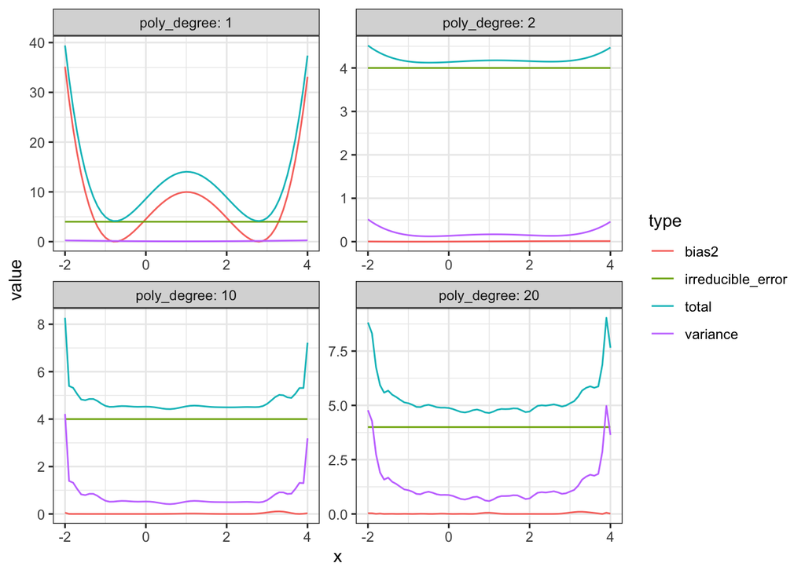

```r
meanmat <- matrix(ncol = length(x), nrow = nord)
varmat <- matrix(ncol = length(x), nrow = nord)
for (j in 1:nord) {
  # We now take the mean over the M simulations
  # - to mimic E and Var at each x value and each poly model
  meanmat[j, ] <- apply(predictions_list[[j]], 2, mean)
  varmat[j, ] <- apply(predictions_list[[j]], 2, var)
}

# Here the truth is finally used!
bias2mat <- (meanmat - matrix(rep(true_y, nord), byrow = TRUE, nrow = nord))^2

df <- data.frame(x = rep(x, each = nord), poly_degree = rep(1:nord, length(x)),
                 bias2 = c(bias2mat), variance = c(varmat),
                 irreducible_error = rep(4, prod(dim(varmat)))) # irr is just 1

df$total <- df$bias2 + df$variance + df$irreducible_error

df_long <- pivot_longer(df, cols = !c(x, poly_degree), names_to = "type")

df_select_poly <- filter(df_long, poly_degree %in% c(1, 2, 10, 20))

ggplot(df_select_poly, aes(x = x, y = value, group = type)) +
  geom_line(aes(color = type)) +
  facet_wrap(~poly_degree, scales = "free", labeller = label_both) +
  theme_bw()
```

We see that the irriducible error remains constant with the complexity (flexibility) of the model and the variance (purple) increases with the complexity. A linear model gives variance close to zero, while a polynomial of degree 20 gives variance close to 1 (larger at the borders). A more complex model is more flexible as it can turn up and down and change direction fast. This leads to larger variance. (Look at the plot in 2a, there is a larger variety of curves you can make when the degree is 20 compared to if the degree is 1.).

Furthermore, we see that the bias is large for poly1, the linear model. The linear model is quite rigid, so if the true underlying model is non-linear, we typically get large deviations between the fitted line and the training data. If we study the first plot, it seems like the fitted line goes through the training data in $x=-1$ and $x=3$ as the bias is close to zero here (this is confirmed by looking at the upper left plot in 2a).

The polynomial models with degree larger than one lead to lower bias. Recall that this is the training bias: The polynomial models will try to pass through the training points if possible, and when the degree of the polynomial is large they are able to do so because they have large flexibility compared to a linear model.

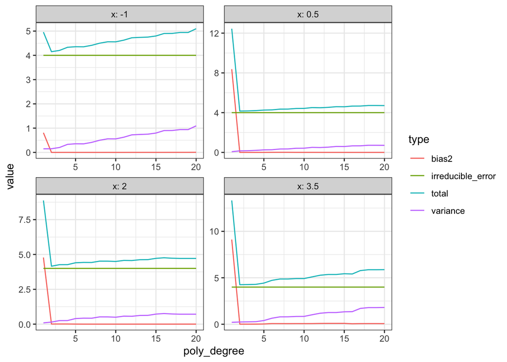

```r
df_select_x <- filter(df_long, x %in% c(-1, 0.5, 2, 3.5))

ggplot(df_select_x, aes(x = poly_degree, y = value, group = type)) +
  geom_line(aes(color = type)) +
  facet_wrap(~x, scales = "free", labeller = label_both) +
  theme_bw()
```

Compare to Figures in 2.12 on page 36 in ISL (our textbook).

4. To change $f(x)$, replace

```r
truefunc <- function(x) return(x^2)
```

by for example

```r
truefunc <- function(x) return(x^4)
```

or

```r
truefunc <- function(x) return(exp(2 * x))
```

and rerun the code. Study the results.

Also change the following part in 2c:

```r
df <- data.frame(x = rep(x, each = nord), poly_degree = rep(1:nord, length(x)),
                 bias2 = c(bias2mat), variance = c(varmat),
                 irreducible_error = rep(4, prod(dim(varmat)))) # irr is just 1
```

to get correct plots of the irreducible error. Here, `rep(4,prod(dim(varmat)))` is replaced by `rep(1,prod(dim(varmat)))`.

# R packages

If you want to look at the .Rmd file and `knit` it, you need to first install the following packages (only once).

```r
install.packages("ggplot2")
install.packages("gamlss.data")
install.packages("tidyverse")
install.packages("GGally")
install.packages("Matrix")
install.packages("patchwork")
```

```r
installed.packages()[names(sessionInfo()$otherPkgs), "Version"]
```

```
##    lubridate      forcats      stringr        dplyr        purrr        readr
##      "1.9.3"      "1.0.0"      "1.5.1"      "1.1.4"      "1.0.2"      "2.1.5"
##        tidyr       tibble    tidyverse    patchwork         MASS       GGally
##      "1.3.1"      "3.2.1"      "2.0.0"      "1.2.0" "7.3-60.0.1"      "2.2.1"
##      ggplot2         ISLR
##      "3.5.0"        "1.4"
```